# Coursera Data Science Capstone Project

Shun-Wen Chang  
10/09/2016

[figure not shown]

### Objective

The purpose of this capstone project is to build a Shiny App that can predict the next word. There are a few steps to complete this project:

- Clean data and first do an exploratory data analysis
- All text data used to create the text dictionary are from [HCCorpora](http://www.corpora.heliohost.org)
- Use analysis of text data and n-gram natural language processing to implement the algorithm
- Create a shiny app that can let user type in a sentence or a paragraph and then predict the next word

### Methodology and Modeling

After extracting a data sample from the HC Corpora database, the sample texts were cleaned by :

- conversion to lowercase
- removing punctuation, links, white space, numbers and all kinds of special characters

Then I tokenized these text data sample into [n-grams](https://en.wikipedia.org/wiki/N-gram) for natural language processing. For this exercise I computed 1-gram to 4-gram. I use the [back-off model](https://en.wikipedia.org/wiki/Katz%27s_back-off_model) for calculation. I select the last 3 words user has typed and start searching for 4-gram. If not found, go with 3-gram…and so on. If nothing is found, return the most frequent one-gram as the next word.

### Shiny App

The next word prediction app is hosted [HERE](https://estherchang.shinyapps.io/Data_Science_captone/). Enter your sentence and hit **Submit** The app will show what your entered and the prediciton for next word. You can type in any amount of words you want.

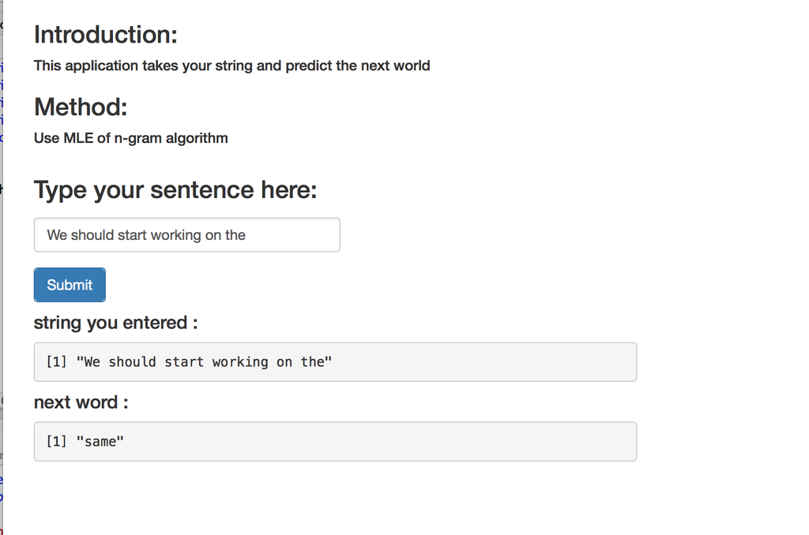

### Additional Information

The whole code of this application, as well as all the milestone report, related scripts, this presentation etc. can be found in my GitHub repo: https://github.com/esther3587/DataScienceCapstone

This R presentation is located here: https://rpubs.com/esther3587/wordpredictor

Learn more about the Coursera Data Science Specialization: https://www.coursera.org/specializations/jhu-data-science

I appreciate Coursera for this specialization and the help from people in the discussion forum.